# Git-Github

### Setup a GitHub account

- https://guides.github.com/activities/hello-world/
- Registration
- Create a Repository

Configure Git with global commands.

- Open the bash version of Git
- git config –global user.name “your GitHub account name” * git config –global user.email “GitHubEmail@something.com”

### Set up Rstudio

- Go to Tools > Options > Git/SVN

[figure not shown]

- Set the path to Git executable (git.exe) file
- Restart RStudio

### Create git Project

- Get your github project url

[figure not shown]

- Project > Create Project > Version Control > Git

[figure not shown]

- copy and paste the github url
- next step is to ‘commit’ your work

### Git stages

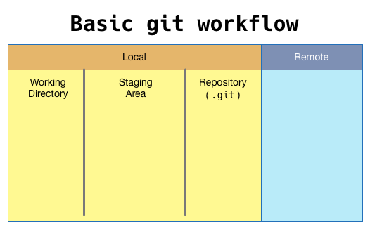

[figure not shown]

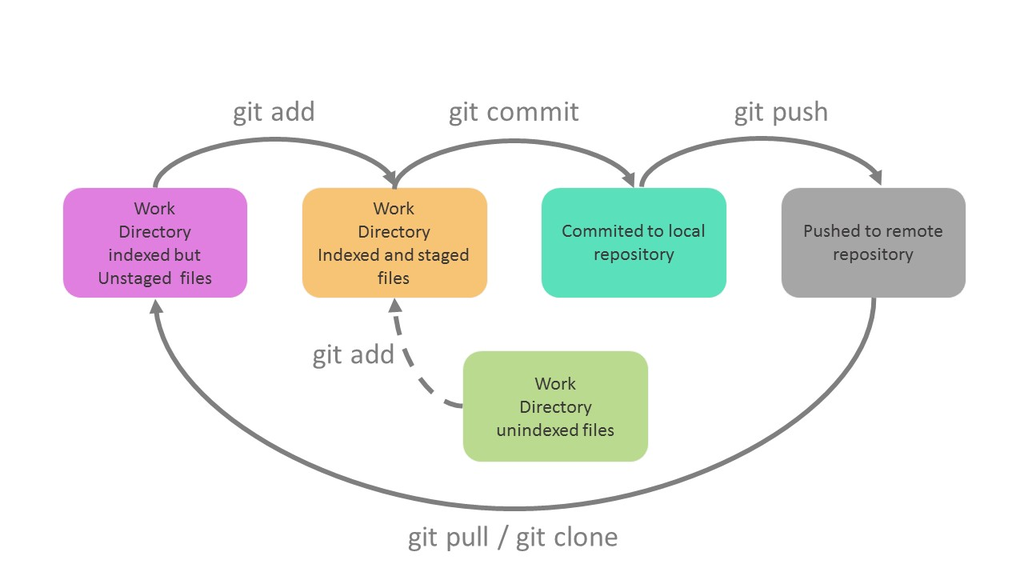

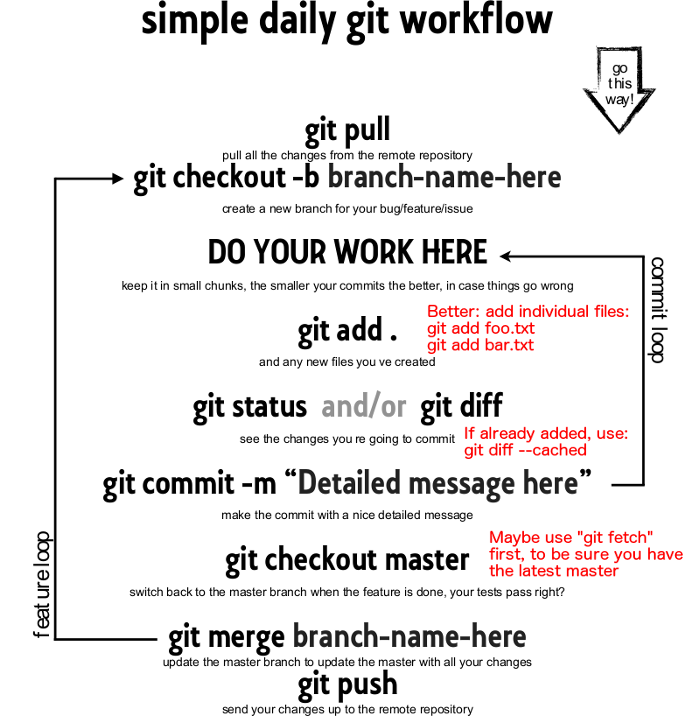

### Create and commit a file

- Make your first commit
- Create a file
- Click the Git tab
  - Check Staged next to .gitignore and your file
  - Click Commit
  - Type a message in Commit message
  - Click Commit

[figure not shown]

- Create a new Rmd file
  - Click File -> New File -> R Markdown
  - Edit the file and change the title
  - Save the file
- Commit the new Rmd file
  - Check Staged and click Commit
- Push to Github
  - Use the push button
  - Go to Github to see your modifications

### SSH

Version control repositories can typically be accessed using a variety of protocols (including http and https). Many repositories can also be accessed using SSH (this is the mode of connection for many hosting services including GitHub and R-Forge).

### Misc

- https://www.youtube.com/watch?v=aM0bjrYCvv8
- http://rogerdudler.github.io/git-guide/index.fr.html
- https://git-scm.com/book/en/v2